# Investigating the Interdependence Among Key Economic Indicators

DATA 608 - Story 2

Author

Kevin Havis

Published

September 19, 2025

## 1 Economic Indicators and their Relationships

The economy, as complex as it is, can be monitored by only a few key parameters. In the United States, some of the most common are Treasury note yields, the Dow Jones Industrial Average (DJIA), and the unemployment rate. Each of these cover very different components of the market, but in aggregate can indicate the market’s overall confidence.

**Dow Jones Industrial Average**: The DJIA covers a broad swathe of United States equities, and does best when the market is encouraged and expecting growth. Equities tend to have the highest rates of return due to their inherent riskier profile compared to bonds and credit instruments. Up ticks in the DJIA indicates a bull market.

**10 Year Treasury Bonds**: Treasury bonds are notes of debt issued by the U.S. Government for a specific tenor (ten years in this case), the rates of which are highly correlated with the overnight rate set by the Fed. These rates are high when the Fed is attempting to restrict growth and potential inflation, and low to encourage a slumped economy. These are typically inversely related to the DJIA.

**Unemployment**: A health economy has a health workforce. Unemployment tends to follow the broad economy trend; a slowing economy means more unemployment, while the a growing one hires reduces it.

The below visual illustrates how these metrics have interacted across the last decade. Their values have been min/max normalized to make them more comparable. Of particular note is the relationship between the DJIA and treasury bonds.

```r
# API Key - Normally wouldn't share this but specified in the instructions
api_key <- "486191162bba8179c3f286918db61916"
url <- "https://api.stlouisfed.org"
url_ext <- "fred/series/observations"
series <- c('DJIA', 'DGS10', 'UNRATE')
start_date <- '2015-10-01'
end_date <- '2024-12-31'

DJIA <- request("https://api.stlouisfed.org") |>
  req_url_path_append(url_ext) |>
  req_url_query(
    api_key = api_key,
    series_id = "DJIA",
    file_type = "json",
    observation_start = start_date, # YYYY-MM-DD formatted string
    observation_end = end_date,
    frequency = 'm'
  ) |>
  req_perform() |>
  resp_body_json()

DGS10 <- request("https://api.stlouisfed.org") |>
  req_url_path_append(url_ext) |>
  req_url_query(
    api_key = api_key,
    series_id = "DGS10",
    file_type = "json",
    observation_start = start_date, # YYYY-MM-DD formatted string
    observation_end = end_date,
    frequency = 'm'
  ) |>
  req_perform() |>
  resp_body_json()

UNRATE <- request("https://api.stlouisfed.org") |>
  req_url_path_append(url_ext) |>
  req_url_query(
    api_key = api_key,
    series_id = "UNRATE",
    file_type = "json",
    observation_start = start_date, # YYYY-MM-DD formatted string
    observation_end = end_date,
    frequency = 'm'
  ) |>
  req_perform() |>
  resp_body_json()


# Extract the data to tibbles
extract_fred_data <- function(response) {
  response$observations |>
    map_dfr(~ tibble(
      date = as.Date(.x$date),
      value = if(.x$value == ".") NA_real_ else as.numeric(.x$value)
    )) |>
    filter(!is.na(value))
}

# Define datasets
djia_data <- DJIA |> extract_fred_data()
dgs10_data <- DGS10 |> extract_fred_data()
unrate_data <- UNRATE |> extract_fred_data()

# Append and melt
combined_data <- bind_rows(
  djia_data |> mutate(series_id = "djia"),
  dgs10_data |> mutate(series_id = "dgs10"),
  unrate_data |> mutate(series_id = "unrate")
) |>
  pivot_wider(
    names_from = series_id,
    values_from = value
  )

combined_data <- combined_data |>
  mutate(across(
    .cols = -date,
    .fns = ~ (. - min(., na.rm = TRUE)) / (max(., na.rm = TRUE) - min(., na.rm=TRUE)),
    .names = "{.col}_normalized"
  ))
```

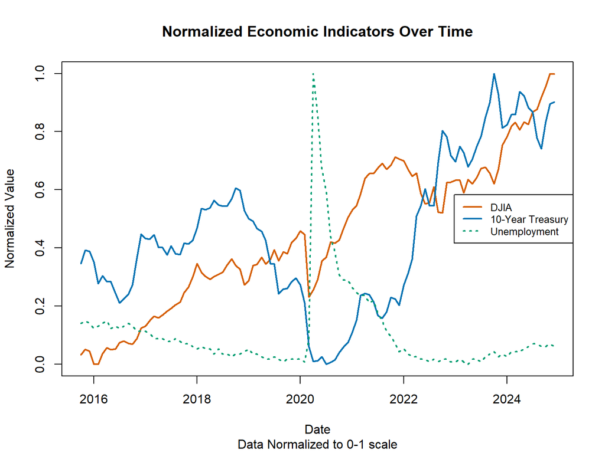

```r
# Plot the time series
combined_data <- combined_data[order(combined_data$date), ]

source_colors <- c("#D55E00", "#0072B2", "#009E73")

plot(
  x=combined_data$date,
  y=combined_data$djia_normalized,
  col = source_colors[1],
  type='l',
  lwd=2,
  lty=1,
  main = "Normalized Economic Indicators Over Time",
  sub = "Data Normalized to 0-1 scale",
  xlab = "Date",
  ylab="Normalized Value"
  )

lines(
  x=combined_data$date,
  y=combined_data$dgs10_normalized,
  col = source_colors[2],
  lwd=2,
  lty=1
  )

lines(
  x=combined_data$date,
  y=combined_data$unrate_normalized,
  col = source_colors[3],
  lwd=2,
  lty=3
  )

legend("right",
       legend = c("DJIA", "10-Year Treasury", "Unemployment"),
       col = source_colors,
       lty = c(1,1,3),
       lwd =2,
       cex = 0.8
)
```